User Manual

[figure not shown]

# Platform Requirements

Hardware Requirements

- Microsoft Windows PC running Microsoft Windows 7 or later

Software Requirements

- Microsoft .NET Framework 4.8 or .NET 6.0

## Installation Options

VECTO is distributed as a portable application. This means you can simply unzip the archive and directly start VECTO.exe. This, however, requires write and execute permissions for the VECTO application directory.

In case you do not have execute permissions, please ask your system administrator to install VECTO into an appropriate directory (e.g. under `C:\Program Files`). Installing VECTO requires the following two steps:

- Copy the VECTO directory and all its files and subdirectories to the appropriate location where the user has execute permissions
- Edit the file `install.ini` and remove the comment character (#) in the line containing `ExecutionMode = install`

If the ExecutionMode is set to `install` (this is also possible when running VECTO from an arbitrary directory), VECTO does not write its configuration files and log files to the application directory but to the directories `%APPDATA%` and `%LOCALAPPDATA%` (usually `C:\Users\<username>\AppData\Roaming` and `C:\Users\<username>\AppData\Local`).

**Important:** If VECTO is run from a directory without write permissions it is necessary that you copy the generic VECTO models distributed with VECTO to a location where you have write permissions or set the output path to a directory with write permissions (see the Options in the main window).

# User Manual

[figure not shown]

Version: VECTO 4.x / VectoCore 4.x / VectoCmd 4.x

VECTO is a tool for the calculation of energy consumption and CO<sub>2</sub> emissions of vehicles. It models the components of a heavy-duty vehicle and simulates a virtual drive on a route. The goal is to provide a standardized way of calculating the energy consumption (fuel consumption) and corresponding CO<sub>2</sub> emissions.

This User Manual consists of 4 Parts:

- **Graphical User Interface:**

  Describes the graphical user interface of VECTO with all windows and configuration possibilities.
- **Calculation Modes:**

  Describes the calculation modes of VECTO (Declaration, Engineering, …).
- **Simulation Models:**

  This chapter describes the used component models and formulas which are implemented in the software.
- **Input and Output:**

  Describes the input and output file formats.

This user manual describes verson 4.x of VECTO.

# User Interface

When VECTO starts the Main Form is loaded. Closing this form will close VECTO even if other dialogs are still open.

- Main Form
- Settings
- Job Editor
- Vehicle Editor - General
- Vehicle Editor - Powertrain
- Vehicle Editor - Electric Machine
- Vehicle Editor - REESS
- Vehicle Editor - IEPC
- Vehicle Editor - IHPC
- Vehicle Editor - GenSet
- Vehicle Editor - Composite Fuel Cell System
- Vehicle Editor - Torque Limits
- Vehicle Editor - ADAS
- Vehicle Editor - PTO
- Aux Dialog
- BusAux Dialog
- Engine Editor
- Gearbox Editor
- Graph Window

## Main Form

[figure not shown]

### Description

The Main Form is loaded when starting VECTO. Closing this form will close VECTO even if other dialogs are still open. In this form all global settings can be controlled and all other application dialogs can be opened.

In order to start a simulation the Calculation Mode must be set and at least one Job File (.vecto) must added to the Job List. After clicking START all checked files in the Job List will be calculated.

The Main Form includes two tabs as described below:

- Job Files Tab
- Options Tab

### Job Files Tab

#### Job Files List

Job files (.vecto) listed here will be used for calculation. Unchecked files will be ignored! Doubleclick entries to edit job files with the VECTO Editor.

**All**

(Un-)Check all files in Job List. Only checked files are calculated when clicking START.

*Add files to Job List*

*Remove selected files from List*

*Move selected files up or down in list*

##### List Options

- **Save/Load List**
  - Save or load Job List to text file
- **Load Autosave-List**
  - The Autosave-List is saved automatically on application exit and calculation start
- **Clear List**
  - Remove all files from Job List
- **Remove Paths**
  - Remove paths, i.e. only file names remain using the Working Directory as source path.

#### *START Button*

Start VECTO in the selected mode (see Options).

### Options Tab

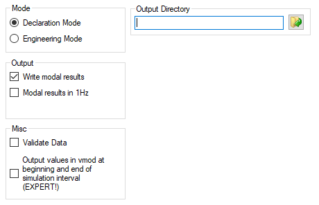

In this tab the global calculation settings can be changed.

**Mode**

Select either Declaration Mode or Engineering Mode

**Output Directory**

This input can be used to write all simulation result files to a certain directory. This can be either an absolute path or a relative path. If an absolute path is provided, all result files are written to this directory. If a relative path is provided the .vmod and XML reports are written into the corresponding subdirectory of the job file and the .vsum file is written to the corresponding subdirectory of the first selected job file.

**Output**

**Write modal results**

Toggle output of modal results (.vmod files) in declaration mode. A Summary file (.vsum) is always created.

**Modal results in 1Hz**

If selected, the modal results (.vmod file) will be converted into 1Hz after the simulation. This may add certain artifacts in the resulting modal results file.

**MISC**

**Validate Data**

Enables or disables internal checks if the model parameters are within a reasonable range. When simulating a new vehicle model it is good to have this option enabled. If the model parameters are from certified components or the model data has only been modified slightly this check may be disabled. The VECTO simulation will abort anyways if there is an error in the model parameters. Enabling this option increases the simulation time by a few seconds.

**Output values in vmod at beginning and end of simulation interval**

By default VECTO writes the simulation results at the middle of every simulation interval. If this option is enabled, the .vmod file will contain two entries for every simulation interval, one at the beginning and one at the end of the simulation interval. Enabling this option may be helpful for analyzing the trace of certain signals but can not be used for quantitative analyses of the fuel consumption, average power losses, etc. The generated modal result file has the suffix ’_sim’. The picture below shows the difference in the output (top: conventional, bottom: if this option is checked)

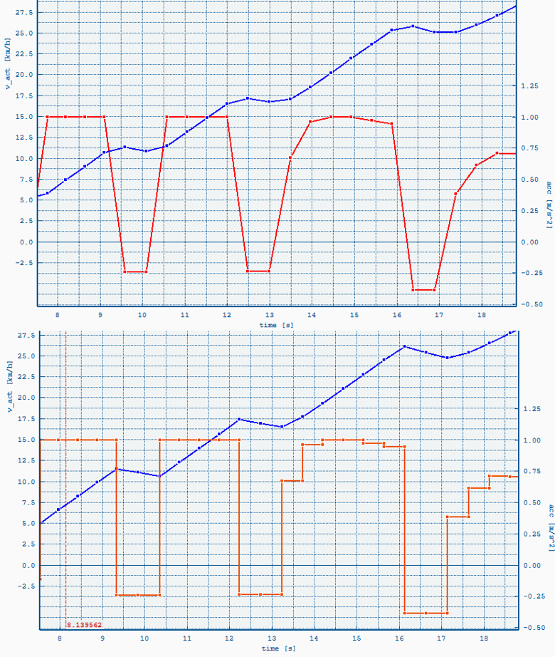

Regular VECTO .vmod output (top) vs. beginning and end of simulation interval (bottom)

### Controls

**New Job File**

Create a new .vecto file using the VECTO Editor

**Open existing Job or Input File**

Open an existing input file (Job, Engine, etc.)

*Tools*

- **Job, Vehicle, Engine, Gearbox Editor**
  - Opens the respective Editor
- **Graph**
  - Open a new Graph Window
- **Open Log**
  - Opens the Log File in the system’s default text editor
- **Settings**
  - Opens the Settings dialog.

*Help*

- **User Manual**
  - Opens this User Manual
- **Release Notes**
  - Open the Release Notes (pdf)
- **Report Bug via CITnet / JIRA**
  - Open the CITnet/JIRA website for reporting bug
- **Create Activation File**
  - Create an Activation File used for Licensing
- **About VECTO**
  - Information about the software, license and support contact

**Message List**

All messages, warnings and errors are displayed here and written to the log file LOG.txt in the VECTO application folder. Depending on the colour the following message types are displayed:

- Status Messages
- Warnings
- Errors
- Links - click to open file/user manual/etc.

Note that the message log can be opened in the Tools menu with **Open Log**.

In addition to the log messages shown in the message list, VECTO writes more elaborate messages in the subdirectory logs. If multiple simulations are run in parallel (e.g., in declaration mode a vehicle is simulated on different cycles with different loadings) a separate log-file is created for every simulation run.

**Statusbar**

Displays current status and progress of active simulations. When no simulation is executed the current mode is displayed (Engineering or Declaration Mode).

## Settings

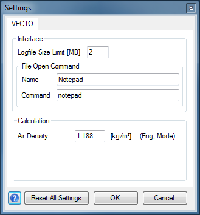

### Description

In the Settings dialog controls general application settings. The settings are saved in the settings.json file.

### Interface Settings

**File Open Command**

This command will be used to open CSV Input Files like Driving Cycles (.vdri). See: [Run command](http://en.wikipedia.org/wiki/Run_command)  
**Name**: Name of the command as it will be shown in the menu when clicking the button.  
**Command**: The actual command.

*Example* *: If the command is* *excel* *and the file is* *C:\VECTO\cycle1.vdri* *then VECTO will run:* *excel “C:\VECTO\cycle1.vdri”*

### Calculation Settings

**Air Density [kg/m³]**

The Air Density is needed to calculate the air resistance together with the **Drag Coefficient** and the **Cross Sectional Area** (see Vehicle Editor).

This setting is only used in Engineering mode. In Declaration mode the default value of 1.188 [kg/m³] is used.

### Controls

**Reset All Settings**

All values in the Settings dialog and Options Tab of the Main Form will be restored to default values.

*Save and close dialog*

*Close without saving*

## Job Editor

[figure not shown]

### Description

The job file (.vecto) includes all informations to run a VECTO calculation. It defines the vehicle and the driving cycle(s) to be used for calculation. In summary it defines:

- Filepath to the Vehicle File (.vveh) which defines the not-engine/gearbox-related vehicle parameters
- Filepath to the Engine File (.veng) which includes full load curve(s) and the fuel consumption map
- Filepath to the Gearbox File (.vgbx) which defines gear ratios and transmission losses
- Filepath to the Gearshift Parameters File (.vtcu) which allows to override parameters of the Effshift Gearshift Strategy. The gearshift parameters cannot be edited via the graphical user interface. In case the default parameters shall be used either an empty .vtcu file (see .vtcu) or the gearbox file (.vgbx) can be provided. An example .vtcu file is provided here
- Auxiliaries
- Driver Assist parameters
- Driving Cycles (only in Engineering Mode)

### Relative File Paths

It is recommended to use relative filepaths. This way the Job File and all input files can be moved without having to update the paths. Example: “Vehicles\Vehicle1.vveh” points to the “Vehicles” subdirectory of the Job File’s directoy.

VECTO automatically uses relative paths if the input file (e.g. Vehicle File) is in the same directory as the Job File. (*Note:* The Job File must be saved before browsing for input files.)

### General Settings

**Engine Only Mode**

Enables Engine Only Mode (Engineering mode only). The following parameters are needed for this mode:

- Filepath to the Engine File (.veng)
- Driving Cycles including engine torque (or power) and engine speed

**Filepath to the Vehicle File (.vveh)**

Files can be created and edited using the Vehicle Editor.

**Filepath to the Engine File (.veng)**

Files can be created and edited using the Engine Editor.

**Filepath to the Gearbox File(.vgbx)**

Files can be created and edited using the Gearbox Editor.

Filepath to the Shift Parameters File(.vtcu)

**Filepath to the Hybrid Strategy Parameters File(.vhctl)**

Files can be created and edited using the Hybrid Strategy Parameters Editor.

### Auxiliaries Tab

[figure not shown]

**Auxiliaries**

This group contains input elements to define the engine’s load from the auxiliaries. In Declaration Mode only the predefined auxiliaries are available and their power-demand is also predefined, depending on the vehicle category and driving cycle. The list contains the predefined auxiliaries where the concrete technology for each auxiliary can be configured using the Auxiliary Dialog. **Double-click** entries to edit with the Auxiliary Dialog. No other types of auxiliaries can be used in declaration mode.

**Auxiliaries**

In Engineering Mode the auxiliary power demand can be defined in three ways.

The first option is to define the power demand directly in the driving cycle in the column “Padd” (see Driving Cycles. This allows to vary the auxiliary load over distance (or time, for time-based driving cycles).

The second option is to define a constant power demand over the whole cycle. The auxiliary power demand can be specified depending on whether the combustion engine is on or off and the vehicle is driving. The auxiliary power demand during engine-off phase is corrected in the post-processing.

The third option is to use the bus-auxiliaries model. For details see the Bus Auxiliaries model.

See Auxiliaries for details.

### Cycles Tab

[figure not shown]

**Cycles**

List of cycles used for calculation. The .vdri format is described here.

In Declaration Mode, the cycles to be simulated depend on the vehicle group. The cycles are listed in this window for reference.

In Engineering Mode the cycles can be freely selected. All declaration cycles are provided in the Folder “Mission Profiles” and can be used or a custom cycle can be created and used.

**Double-click** an entry to open the file (see File Open Command).

**Click** selected items to edit file paths.**

Add cycle (.vdri)

Remove the selected cycle from the list

### Driver Model Tab

[figure not shown]

In this tab the driver assistance functions are enabled and parameterized. The parameters for overspeed, look-ahead coasting and driver acceleration can only be modified in Engineering Mode.

**Overspeed**

See Overspeed for details.

**Look-Ahead Coasting**

See Look-Ahead Coasting for details.

**Acceleration Limiting**

See Acceleration Limiting for details.

### ADAS Parameters

[figure not shown]

In this tab certain general parameters for the advanced driver assistant system model can be set. Which ADAS feature is available can be selected in the vehicle itself, in Engineering Mode parameters like minimum activation speed, activation delay, or allowed overspeed can be adjusted. In Declaration Mode all parameters are fixed.

For details on the individual parameters see the corresponding section Engine Stop/Start, Eco-Roll, Predictive Cruise Control

### Chart Area

The chart area on the right shows the main vehicle parameters like HDV group and axle configuration if a valid Vehicle File, Engine File and Gearbox File is loaded into the Editor. The plot shows the full load curve(s) and sampling points of the fuel consumption map.

### Controls

**New Job File**

Create a new empty .vecto file

**Open existing Job File**

Open an existing .vecto file

*Save current Job File*

*Save Job File as…*

**Send current file to Job List in Main Form**

**Note:** The file will be sent to the Job List automatically when saved.

*Open Vehicle Editor*

*Open Engine Editor*

*Open Gearbox Editor*

*Browse for vehicle/engine/gearbox files*

**Save and close file**

File will be added to Job List in the Main Form.

*Cancel without saving*

## VTP-Job Editor

[figure not shown]

### Description

A VTP-Job is intended to verify the declared data of a vehicle through an on-road test. VTP-Jobs can be either simulated in engineering mode or declaration mode. For a VTP simulation the measured driving cycle along with the VECTO job-file is required. The driving cycle has to contain the vehicle’s velocity, rotational speed of the driven wheels, torque of the driven wheels, fuel consumption, engine speed, engine torque, engine fan speed or power, and pollutants flow in a temporal resolution of 2Hz. VECTO computes the best matching gear based on the vehicle parameters, the actual vehicle speed and the engine speed. Next, VECTO re-computes the fuel consumption based for the given driving cycle. For a VTP-test the re-computed fuel consumption has to be within certain limits of the real fuel consumption.

The VTP job file (.vecto) includes all the necessary information to run a VECTO calculation. It defines the vehicle and the driving cycle(s) to be used for the calculations. In summary, it defines:

- Filepath to the Vehicle File (.xml) which defines all relevant parameters, including all components
- Driving Cycles

In engineering mode multiple driving cycles can be specified

In declaration mode only the first given driving cycle is simulated as the results are further compared with the re-simulated results of the reference cycle. The reference cycle is the first driving cycle applicable for the actual vehicle group as listed in the Job Window and provided in the reports (i.e., LongHaul for most heavy lorries).

In declaration mode the manufacturer’s record file needs to be provided. Furthermore, declaration mode simulations consider correction factors for the net calorific value of the used fuel(s) and the vehicle’s mileage. In engineering mode the according input fields are not shown. The fields for the net calorific values are shown only after the vehicle XML has been loaded, because it defines the fuel types used.

### Relative File Paths

It is recommended to use relative filepaths. This way the Job File and all input files can be moved without having to update the paths. Example: “Vehicles\Vehicle1.xml” points to the “Vehicles” subdirectory of the Job File’s directory.

VECTO automatically uses relative paths if the input file (e.g. Vehicle File) is in the same directory as the Job File. (*Note:* The Job File must be saved before browsing for input files.)

**Cycles**

List of cycles used for calculation. The .vdri format is described here. **Double-click** an entry to open the file (see File Open Command). **Click** selected items to edit file paths.

Add cycle (.vdri)

Remove the selected cycle from the list

### Chart Area

The chart area on the right shows the main vehicle parameters like HDV group and axle configuration if a valid Vehicle File is loaded into the Editor. The plot shows the full load curve(s) and sampling points of the fuel consumption map.

### Controls

**New Job File**

Create a new empty .vecto file

**Open existing Job File**

Open an existing .vecto file

*Save current Job File*

*Save Job File as…*

**Send current file to Job List in Main Form**

**Note:** The file will be sent to the Job List automatically when saved.

*Browse for vehicle file*

**Save and close file**

File will be added to Job List in the Main Form.

*Cancel without saving*

## Auxiliary Dialog

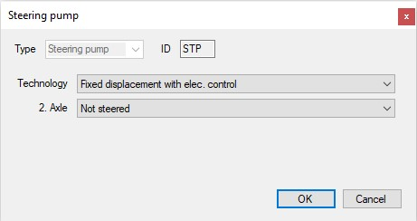

Auxiliary Dialog (Declaration Mode)

### Description

The Auxiliary Dialog is used to configure auxiliaries. In Declaration Mode the set of auxiliaries and their power demand is predefined. For every auxiliary the user has to select the technology from a given list.

### Settings

**Technology**

List of available technology for the auxiliary type For the steering pump multiple technologies can be defined, one for each steered axle.

### Controls

*Save and close*

*Close without saving*

In Engineering Mode the auxiliary power demand can either be specified in the driving cycle over distance (or time), specified as constant load, or via the bus auxiliaries. For more details see the Auxiliaries tab in the Job editor.

## BusAuxiliary Dialog

[figure not shown]

In Engineering Mode the electrical and mechanical power demand for the electric system, the pneumatic system and the HVAC can be provided.

#### Electric System

**Current Demand Engine On [A]**

Demand of the electric system when the ICE is on. The current is multiplied with the nominal voltage of 28.3V.

**Current Demand Engine Off Driving [A]**

Demand of the electric system when the ICE is off and the vehicle is driving. The current is multiplied with the nominal voltage of 28.3V.

**Current Demand Engine Off Standstill [A]**

Demand of the electric system when the ICE is off and the vehicle is at standstill. The current is multiplied with the nominal voltage of 28.3V.

**Alternator Efficiency [-]**

The electric power demand is divided by the alternator efficiency to get the mechanical power demand at the crank shaft

**Alternator Technology**

The “conventional alternator” generated exactly the electric power as demanded by the auxiliaries. The “smart alternator” may generate more electric power than needed during braking phases. The excessive electric power is stored in a battery. In case “no alternator” is selected (only available for xEV vehicles) the electric system is supplied from the high voltage REESS via a DC/DC converter.

**Max Recuperation Power [W]**

In case of a smart alternator, defines the maximum electric power the alternator can generate during braking phases.

**Useable Electric Storage Capacity [Wh]**

In case of a smart alternator, defines the storage capacity of the battery. In case the battery is not empty, the electric auxiliaries are supplied from the battery. Excessive electric energy from the smart alternator during braking phases is stored in the battery.

**Electric Storage Efficiency [-]**

This efficiency is applied when storing electric energy from the alternator in the battery.

**ES supply from HEV REESS**

If selected, the low-voltage electric auxiliaries can be supplied from the high voltage REESS via the DC/DC converter. Needs to be selected in case “no alternator” is chosen as alternator technology. In case of a smart alternator, the low-voltage battery is used first and if empty the energy is drawn from the high voltage system.

**DC/DC Converter Efficiency [-]**

In case the electric system is supplied by the high voltage REESS, the efficiency of the DC/DC converter can be defined via a constant efficiency value

#### Pneumatic System

**Compressor Map**

Compressor map file defining the mechanical power demand and the air flow depending on the compressor speed.

**Average Air Demand [NI/s]**

Defines the average demand of compressed air throughout the cycle.

**Compressor Ratio [-]**

Defines the ratio between the air compressor and combustion engine

**Smart Air Compressor**

If enabled, the air compressor may generate excessive air during braking events. The air consumed and generated are corrected in post processing.

#### HVAC System

**Mechanical Power Demand [W]**

Power demand of the HVAC system directly applied at the crank shaft

**Electric Power Demand [W]**

Electric power demand of the HVAC system. This is added to the current demand of the electric system

**Aux Heater Power [W]**

Maximum power of the auxiliary heater

**Average Heating Demand [MJ]**

Heating demand for the passenger compartment. This demand is primary satisfied from the combustion engines waste heat. In case the heating demand is higher, the auxiliary heater may provide additional heating power. The fuel consumption of the aux heater is corrected in post processing.

## Vehicle Editor – General Tab

[figure not shown]

### Description

The Vehicle File (.vveh) defines the main vehicle/chassis parameters like axles including RRCs, air resistance and masses.

The Vehicle Editor contains up to 8 tabs, depending on the powertrain architecture and simulation mode, to edit all vehicle-related parameters. The ‘General’ tab allows to input mass, loading, air resistance, vehicle axles, etc. The ‘Powertrain’ tab allows to define the retarder, an optional angle drive and an optional NG Tank System. The ‘Electric Machine’ tab is dedicated to all electric components used to propell the vehicle in case of hybrid electric and battery electric vehicles. The ‘REESS’ tab covers all inputs related to the rechargeable electric energy storage system. The ‘GenSet Components’ tab is only available for serial hybrid vehicles and contains all input fields required to define the electric machine used to generate electricity via the ICE. In the ‘Torque Limits’ tab the torque limitations for the combustion engine, the electric motor and the whole vehicle can be specified. The ‘ADAS’ tab allows to enable or disable certain advanced driver assistant systems to be considered in the vehicle. The ‘PTO’ tab is dedicated to PTOs, either as a basic component or to simulate municipal vehicles such as refuse trucks or road sweepers with dedicated PTO activation either during driving or during standstill.

### Relative File Paths

It is recommended to use relative filepaths. This way the Job File and all input files can be moved without having to update the paths. Example: “Demo\RT1.vrlm” points to the “Demo” subdirectory of the Vehicle File’s directoy.

VECTO automatically uses relative paths if the input file (e.g. Retarder Losses File) is in the same directory as the Vehicle File. (*Note:* The Vehicle File must be saved before browsing for input files.)

### General vehicle parameters

**Vehicle Category**

Needed for Declaration Mode to identify the HDV Group.

**Axle Configuration**

Needed for Declaration Mode to identify the HDV Group.

**Technically Permissible Maximum Laden Mass [t] (TPMLM)**

Needed for Declaration Mode to identify the HDV Group.

**HDV Group**

Displays the automatically selected HDV Group depending on the settings above.

### Masses/Loading

**Corrected Actual Curb Mass Vehicle**

Specifies the vehicle’s mass without loading

**Curb Mass Extra Trailer/Body**

Specifies additional mass due to superstructures on the vehicle or an additional trailer

**Loading**

Specifies the loading of both, the vehicle and if available the trailer

**Max. Loading** displays a hint for the maximum possible loading for the selected vehicle depending on curb mass and TPMLM values (without taking into account the loading capacity of an additional trailer).

*Note:* *VECTO uses the sum of* *Corrected Actual Curb Mass Vehicle, Curb Mass Extra Trailer/Body* *and* *Loading* *for calculation! The total mass is distributed to all defined axles according to the relative axle load share.*

In Declaration Mode only the vehicle itself needs to be specified. Depending on the vehicle category and mission the simulation adds a standard trailer for certain missions.

### Air Resistance and Cross Wind Correction Options

The product of Drag Coefficient [-] and Cross Sectional Area [m²] (**c<sub>d</sub> x A**) and **Air Density** [kg/m³] (see Settings) together with the vehicle speed defines the Air Resistance. Vecto uses the combined value **c<sub>d</sub> x A** as input. **Note that the Air Drag depends on the chosen **Cross Wind Correction**.**

If the vehicle has attached a trailer for simulating certain missions the given **c<sub>d</sub> x A** value is increased by a fixed amount depending on the trailer used for the given vehicle category.

**For cross wind correction four different options are available (see Cross Wind Correction for details):**

- No Correction: The specified CdxA value is used to compute the air drag, no cross-wind correction is applied
- Speed dependent (User-defined): The specified CdxA value is corrected depending on the vehicle’s speed.
- Speed dependent (Declaration Mode): A uniformly distributed cross-wind is assumed and used for correcting the air-drag depending on the vehicle’s speed
- Vair & Beta Input: Correction mode if the actual wind speed and wind angle relative to the vehicle have been measured.

In delcaration mode the ‘Speed dependent (Declaration Mode)’ cross-wind correction is used.

Depending on the chosen mode either a Speed Dependent Cross Wind Correction Input File (.vcdv) or a Vair & Beta Cross Wind Correction Input File (.vcdb) must be defined. For details see Cross Wind Correction.

### Dynamic Tyre Radius

In Engineering Mode this defines the effective (dynamic) wheel radius (in [mm]) used to calculate engine speed. In Declaration Mode the radius calculated automatically using tyres of the powered axle.

### Axles/Wheels

For each axle the parameters **Relative axle load, RRC<sub>ISO</sub>** and **F<sub>zISO</sub>** have to be given in order to calculate the total Rolling Resistance Coefficient. For non-driven axles the user can edit the wheel end friction.

In Engineering mode, the **Wheels Inertia [kgm²]** has to be set per wheel for each axle. The axles, for both truck and trailer, have to be given.

Use the and buttons to add or remove axles form the vehicle.

In Declaration mode only the axles of the truck have to be given (e.g., 2 axles for a 4x2 truck). The dynamic tire radius is derived from the second axle as it is assumed this is the driven axle. For missions with a trailer, predefined wheels and load-shares are added by VECTO automatically.

Doubleclick entries to edit existing axle configurations.

### Controls

**New file**

Create a new empty .vveh file

**Open existing file**

Open an existing .vveh file

*Save current file*

*Save file as…*

**Send current file to the VECTO Editor**

**Note:** If the current file was opened via the VECTO Editor the file will be sent automatically when saved.

**Save and close file**

If necessary the file path in the VECTO Editor will be updated.

*Cancel without saving*

## Vehicle Editor – Powertrain Tab

[figure not shown]

### Vehicle Idling Speed

The idling speed of the combustion engine can be increased in the vehicle settings. This may be necessary due to certain auxiliaries or for other technical reasons. This value is only considered if it is higher than the idling speed defined in the combustion engine.

### Retarder Losses

If a separate retarder is used in the vehicle a **Retarder Torque Loss Map** can be defined here to consider idling losses caused by the retarder.

The following options are available: - None: No retarder present in the vehicle - Included in Transmission Loss Maps: Use this if the Transmission Loss Maps already include retarder losses. - Transmission Input Retarder: The rpm ratio is relative to the engine speed. - Transmission Output Retarder: The rpm ratio is relative to the cardan shaft speed. - Engine Retarder: Used this if the engine already includes the retarder losses. - Axlegear Input Retarder (after axle gear): The rpm ratio is relative to the axle gear input shaft speed. Only available for battery electric vehicles with E3 motor, serial hybrid with S3 motor, IEPC-S, and IEPC-E.

Transmission Input. Transmission Output and axle gear input retarder require an Retarder Torque Loss Input File (.vrlm). The retarder ratio defines the ratio between the engine speed/cardan shaft speed and the retarder.

### Angledrive

If an angledrive is used in the vehicle, it can be defined here. Note that angledives can only be declared for conventional and parallel hybrid electric vehicles.  
Three options are available:

- None (**default**)
- Separate Angledrive: Use this if the angledrive is measured separately. In this case the ratio must be set and the Transmission Loss Map (or an Efficiency value in Engineering mode) must also be given.
- Included in Transmission Loss Map: Use this if the gearbox already includes the transmission losses for the angledrive in the respective transmission loss maps.

## Vehicle Editor – Electric Machine Tab

[figure not shown]

For hybrid vehicles and battery electric vehicles the input elements on the *electric machine* tab is enabled. Here the component file for the electric motor can be loaded or created (see Electric Motor Editor)

The position where the electric machine is located in the powertrain can be selected. It is possible that the electric machine is connected to the powertrain via a fixed gear ratio. At the moment electric machines are supported to be present at a single position only. It is not possible to have an electric motor at position P2 and another at position P4! However, it is possible that more than one electric machine is used at a certain position.

The *Loss map EM ADC* can be used to consider the losses of a transmission step between drivetrain and electric machine or to consider losses of a summation gear. The loss map has the same format as for all other transmission components (see Transmission Loss Map (.vtlm)). For simplicity or if no such transmission step is used it is possible to enter the efficiency directly (i.e., “1” if no transmission step is used).

In case of a P2.5 configuration (the electric motor is connected to an internal shaft of the transmission) the transmission ratio for every single gear of the transmission has to be specified in the list to the right of the electric motor parameters. The ratio is defined as $n_\textrm{GBX,in} / n_\textrm{EM}$ in case of EM without additional ADC or $n_\textrm{GBX,in} / n_\textrm{ADC,out}$ in case of EM with additional ADC.

## Vehicle Editor – Composite Fuel Cell System Tab

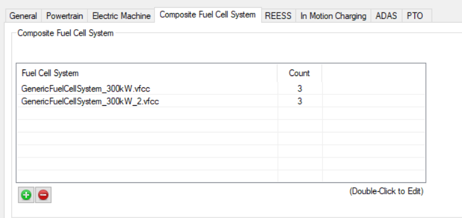

Composite Fuel Cell System Tab

For fuel cell hybrid vehicles the input element on the *Composite Fuel Cell System* tab is enabled.

Here the FCS file for the FCS-String can be loaded or created (see Fuel Cell System String Editor)

The number of *Fuel Cell System Strings (FCS-String)* limited to *two*, each of them supports up to *three* *Fuel Cell Systems (FCS)*.

**Double-click** an entry to edit.

**Click** selected item.**

Add Fuel Cell System File (.vfcc)

Remove the selected Fuel Cell System File from the list

In the Fuel Cell System Dialog, the Fuel Cell System File itself, and the number of fuel cell systems in the string can be modified. (see Fuel Cell System Model for details)

[figure not shown]

Fuel Cell System Dialog

## Vehicle Editor – REESS Tab

[figure not shown]

For hybrid vehicles and battery electric vehicles the input elements on the *rechargeable electric energy storage system (REESS)* tab is enabled. Here the component file for the battery pack can be loaded or created (see Electric Energy Storage Editor)

For the electric energy storage multiple battery packs can be configured either in series or in parallel and the initial state of charge of the whole battery system can be defined. For every entry of a battery pack the number of packs (count) in series and a stream identifier need to be specified. Battery packs on the same stream are connected in series (e.g., two different battery packs on stream number 1 are in series) while all streams are then connected in parallel (see Battery Model for details). This is only supported for batteries and **not** for SuperCaps. Moreover, if the vehicle is capable of ‘Off-Vehicle Charging’, the max. charging power allowed by the vehicle shall be declared (this information is needed to calculate the utility factor and hence the final fuel and/or energy consumption).

**Double-click** an entry to edit.

**Click** selected item.**

Add REESS (.vbat)

Remove the selected REESS from the list

In the REESS Dialog the battery file itself and how it is connected to the electric system (i.e, the stream identifier and number of packs used) can be modified.

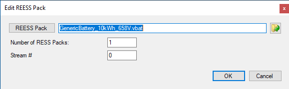

BatteryPackDialog

## Vehicle Editor – In-motion Charging Tab

[figure not shown]

In engineering mode the following model parameters are necessary:

- Share of in-motion charging infrastructure available on total mission distance
- Delta CdxA with active in-motion charging feature
- In-motion charging feature only available on motorway sections

The influence of these parameters is described here

[figure not shown]

In declaration mode only the available in-motion charging technology needs to be selected.

## Vehicle Editor – IEPC Tab

[figure not shown]

For battery electric vehicles of type IEPC-E or hybrid vehicles of type IEPC-S, the tab for the *integrated electric powertrain component (IEPC)* is visible. Here the component file for the IEPC can be loaded or created (see IEPC Editor).

## Vehicle Editor – IHPC Tab

[figure not shown]

For hybrid vehicles if type IHPC the input tab for *integrated hybrid powertrain component (IHPC)* is visible. Here the component file for the electric machine part of the IHPC can be loaded or created (see IHPC Editor)

## Vehicle Editor – GenSet Tab

[figure not shown]

For serial hybrid vehicles the *GenSet tab* is visible. On this tab the electric machine used as generator connected to the combustion engine can be specified (see Electric Motor Editor). It is possible to have multiple equal electric machines as generator. The electric machines can be connected via a transmission to the combustion engine.

The *Loss map EM ADC* can be used to consider the losses of a transmission step between drivetrain and electric machine or to consider losses of a summation gear. The loss map has the same format as for all other transmission components (see Transmission Loss Map (.vtlm)). For simplicity or if no such transmission step is used it is possible to enter the efficiency directly (i.e., “1” if no transmission step is used).

## Vehicle Editor – Torque Limits Tab

[figure not shown]

On this tab different torque limits can be applied at the vehicle level. For details which limits are applicable and who the limits are applied in the simulation see here.

First, the maximum torque of the ICE may be limited for certain gears (see Engine Torque Limitations). In case that the gearbox’ maximum torque is lower than the engine’s maximum torque or to model certain features like Top-Torque (where in the highest gear more torque is available) it is possible to limit the engine’s maximum torque depending on the engaged gear.

Next, the maximum available torque for the electric machine can be reduced at the vehicle level, both for propulsion and recuperation. The input file is the same as the maximum drive and maximum recuperation curve (see Electric Motor Max Torque File)

Last, the overall propulsion of the vehicle (i.e., HEV Px, electric motor plus combustion engine) can be limited. The “Boosting Torque Limit” curve limits the maximum effective torque at the gearbox input shaft over the input speed. This curve is added to the combustion engine’s maximum torque curve (only positive values are allowed!). For details on the file format see Vehicle Boosting Limits. The propulsion torque limit has to be provided from 0 rpm to the maximum speed of the combustion engine. In case of P3 or P4 configuration, the torque at the gearbox input shaft is calculated assuming that the electric motor does not contribute to propelling the vehicle, considering the increased losses in the transmission components in between. For P2.5 powertrain configurations no special calculations are necessary as this architecture is internally anyhow modeled as P2 architecture.

## Vehicle Editor – ADAS Tab

[figure not shown]

On the ADAS tab, the advanced driver assistant systems present in the vehicle can be selected. See ADAS - Engine Stop/Start, ADAS - EcoRoll, ADAS - Predictive Cruise Control, and ADAS - Eco-Roll: Release Lockup Clutch

The following table describes which ADAS technology can be used and is supported for different powertrain architectures (X: supported, O: optional, -: not supported):

[output not shown]

- Engine Stop/Start not allowed for PEV
- EcoRoll for HEV always with ICE off
- For PEV no clutch for disconnecting the EM present, thus no EcoRoll foreseen (very low drag of EM in any case)
- Inputs for EcoRoll possible in GUI, but no effect in simulation

## Vehicle Editor – PTO Tab

[figure not shown]

### PTO Transmission

If the vehicle has a PTO consumer, a pto transmission and consumer can be defined here. (Only in Engineering Mode)

Three settings can be set:

- PTO Transmission (PTO Design Variant): Here a transmission type can be chosen (adds constant load at all times).
- PTO Consumer Loss Map (.vptoi): Here the PTO Idle Loss Map of the pto consumer can be defined (adds power demand when the pto cycle is not active).
- PTO Cycle (.vptoc / .vptoel): Defines the PTO Cycle .vptoc in case of a mechanical PTO declared or PTO Cycle .vptoel in case of an electrical PTO declared. Those cycles are performed in the simulation when the vehicle is standing and the pto-cycle is activated (when the PTO-Flag in the driving cycle is set). Note that an electrical PTO is only valid for battery electric and serial hybrid electric vehicles.

In engineering mode additional PTO activations are available to simulate different types of municipal vehicles. It is possible to add a certain PTO load during driving while the engine speed and gear is fixed (to simulate for example roadsweepers), or to add PTO activation while driving (to simulate side loader refuse trucks for example). In both cases the PTO activation is indicated in the driving cycle (column “PTO”).

### Roadsweeper operation

PTO activation mode 2 simulates PTO activation while driving at a fixed engine speed and gear. The minimum engine speed and working gear is entered in the PTO tab. For details see PTO.

### Sideloader operation

PTO activation mode 3 simulates a time-based PTO activation while driving. Therefore, a separate PTO cycle (.vptor) containing the PTO power over time has to be provided. The start of PTO activation is indicated with a ‘3’ in the ‘PTO’ column of the driving cycle. For details see PTO.

## Engine Editor

[figure not shown]

### Description

The Engine File (.veng) defines all engine-related parameters and input files like Fuel Consumption Map and Full Load Curve.

### Relative File Paths

It is recommended to use relative filepaths. This way the Job File and all input files can be moved without having to update the paths. Example: “Demo\FLD1.vfld” points to the “Demo” subdirectory of the Engine File’s directory.

VECTO automatically uses relative paths if the input file (e.g. FC Map) is in the same directory as the Engine File. *Note:* The Engine File must be saved before browsing for input files.)

### Main Engine Parameters

**Make and Model**

Free text defining the engine model, type, etc.

**Idling Engine Speed [rpm]**

Low idle, applied in simulation for vehicle standstill in neutral gear position.

**Displacement [ccm]**

Used in Declaration Mode to calculate inertia.

**Inertia including Flywheel [kgm²]**

Inertia for rotating parts including engine flywheel. In Declaration Mode the inertia is calculated depending on the engine’s displacement and also accounts for the clutch’s inertia.

**Rated Speed [rpm]**

This value represents the characteristic rated speed of the engine. It is not used in the simulation as the rated speed is derived from the full-load curve

**Rated Power [kW]**

This value represents the characteristic rated power of the engine. It is not used in the simulation as the rated power is derived from the full-load curve

**Max Torque [Nm]**

This value represents the characteristic maximum torque of the engine. It is not used in the simulation as the maximum torque is derived from the full-load curve

**Dual Fuel Engine**

If enabled, a secondary fuel can be specified.

### Primary/Secondary Fuel

**Fuel Type**

Used to compute derived results such as fuel consumption in liters and CO2 values. This parameter influences the CO2-to-fuel ratio and fuel density. The actual values can be looked up in FuelTypes.csv.

**Full Load and Drag Curves**

The Engine’s Full Load and Drag Curves (.vfld) limits the engine’s maximum torque and drag torque respectively The full-load curve must at least cover the engine-speed range from idling speed up to the speed where the power goes down to 70% of the maximum power. The input file (.vfld) file format is described here.

**Fuel Consumption Map**

The Fuel Consumption Map is used to calculate the base FC value. See Fuel Consumption Calculation for details. The input file (.vmap) file format is described here.

**WHTC Correction Factors**

The WHTC Correction Factors are required in Declaration Mode for the WHTC FC Correction.

The Cold/Hot Emission Balancing Factor is an additional correction factor that is used to correct the fuel consumption.

In engineering a single correction factor for correcting WHTC, Cold/Hot Balancing, … can be specified.

### Dual Fuel Engines

If the engine is operated in dual-fuel mode, enabling the checkbox “Dual Fuel Engine” shows an additional tab for providing the fuel type, fuel consumption map, and fuel consumption correction factors for the second fuel. For dual-fuel engines the result files (.vmod, .vsum, XML reports) contain the fuel consumption for each fuel separately and the total CO2 emissions.

### Waste Heat Recovery

[figure not shown]

In case the engine is equipped with a waste heat recovery system (WHR) the WHR type can be selected in the lower right part of the window. For WHR systems that generate mechanical power that is directly delivered to the engine’s crankshaft no further input is required - the WHR shall be considered in the fuel consumption map already.

For WHR systems with electrical power output the generated electrical power needs to be provided in the Fuel Consumption Map of the primary fuel.

For WHR systems with mechanical power output to the drivetrain the generated mechanical power needs to be provided in the Fuel Consumption Map of the primary fuel.

The final fuel consumption is at the end corrected for the electric and mechanical energy generated by the WHR system (see fuel consumption correction) Similar correction factors as applied for the fuel consumption (WHR Correction factors) have to be provided for the WHR system. The weighting of these correction factors is the same as for the WHTC correction factors.

### Chart Area

The Chart Area shows the fuel consumption map and the selected full load curve. The fuel consumption map of the primary fuel is plotted in red and if provided the secondary fuel is plotted in green.

### Controls

**New file**

Create a new empty .veng file

**Open existing file**

Open an existing .veng file

*Save current file*

*Save file as…*

**Send current file to the VECTO Editor**

**Note:** If the current file was opened via the VECTO Editor the file will be sent automatically when saved.

*Open file browser*.

*Open file* (see File Open Command).

**Save and close file**

If necessary the file path in the VECTO Editor will be updated.

*Cancel without saving*

## Gearbox Editor

[figure not shown]

### Description

The Gearbox File (.vgbx) defines all gearbox-related input parameters like gear ratios and transmission loss maps. Furthermore, certain parameters for the gearshift strategy such as the gearshift lines can be provided (see Gear Shift Model for details).

### Relative File Paths

It is recommended to use relative filepaths. This way the Job File and all input files can be moved without having to update the paths.  
Example: “Gears\Gear1.vtlm” points to the “Gears” subdirectory of the Gearbox File’s directory.

VECTO automatically uses relative paths if the input file (e.g. Shift Polygons File) is in the same directory as the Gearbox File. (The Gearbox File must be saved before browsing for input files.)

### Main Gearbox Parameters

**Make and Model**

Free text defining the gearbox model, type, etc.

**Transmission Type**

Depending on the vehicle type some options below are not available. The following types are available:

- **MT**: Manual Transmission
- **AMT**: Automated Manual Transmission
- **APT-S**: Automatic Transmission with torque converter - Serial configuration
- **APT-P**: Automatic Transmission with torque converter - Power Split configuration
- **APT-N**: Automatic Transmission without torque converter, only applicable for pure electric vehicles
- **IHPC**: Transmission for IHPC configuration
- **IEPC**: Transmission for IEPC-S and IEPC-E configuration (dummy entry)

For more details on the automatic transmission please see the APT-Model

**Inertia [kgm²]**

Rotational inertia of the gearbox (constant for all gears). (Engineering mode only)

**Traction Interruption [s]**

Interruption during gear shift event. (Engineering mode only)

### Gears

Use the and buttons to add or remove gears from the vehicle. Doubleclick entries to edit existing gears.

- Gear **“Axle”** defines the ratio of the axle transmission / differential.
- **“Ratio”** defines the ratio between the input speed and output speed for the current gear. Must be greater than 0.
- **“Loss Map or Efficiency”** allows to define either a constant efficiency value or a loss map (.vtlm). Note: efficiency values are only allowed in engineering mode
- **“Shift polygons”** defines the Shift Polygons InputFile (.vgbs) for each gear. Not allowed in Declaration Mode. See GearShift Model for details.
- **“Max Torque”** defines the maximum allowed torque (if applicable) for a gear. It is used for limiting the engine’s torque in certain gears. Note: in Declaration mode the generic shift polygons are computed from the engine’s full-load curve. If the maximum torque is limited by the gearbox, the minimum of the gearbox and engine maximum torque will be used to compute the generic shift polygons!
- **“Max Speed”** define the maximum speed for the current gear

### Gear shift strategy parameters

[figure not shown]

Some parameters influencing the gearshift behavior can be defined in the gearbox file. Therefore, the gearbox file has to be provided as input for the shift strategy parameters as well. See Gearbox-TCU for more details.

In addition, the gearshift polygon affects the gearshift behavior to a certain degree. The gearshift polygon can be defined individually for each gear. If no shift polygon is provided the declaration mode shift polygons for the selected transmission type are used.

The gearshift strategy depends on the specific combination of vehicle and transmission type:

**Manual Transmission**

Shiftline based approach. The calculation of gearshift lines and the gearshift rules are described here

**Automated Manual Transmission - Conventional vehicle**

Efficiency shift. The calculation of gearshift lines and the gearshift rules are described here

**Automated Manual Transmission - Hybrid Electric vehicle**

Gearshift is handled by the hybrid controller. Shift lines (calculated in the same way as for conventional vehicles) are used as upper and lower boundary for allowed ICE operating points.

**Automated Manual Transmission - Pure Electric vehicle**

Efficiency shift based strategy. The calculation of gearshift lines and the gearshift rules are described here

**Automatic Transmission - Conventional vehicle**

Efficiency shift. The calculation of gearshift lines and the gearshift rules are described here

**Automatic Transmission - Hybrid Electric vehicle**

Gearshift is handled by the hybrid controller. Shift lines (calculated in the same way as for conventional vehicles) are used as upper and lower boundary for allowed ICE operating points.

**Automatic Transmission (APT-N) - Pure Electric vehicle**

Efficiency shift based strategy. The calculation of gearshift lines and the gearshift rules are described here

**Automated Manual Transmission (IHPC Transmission) - IHPC-Type 1**

Gearshift is handled by the hybrid controller. Shift lines (calculated in the same way as for conventional vehicles) are used as upper and lower boundary for allowed ICE operating points.

**Automatic Transmission (APT-N) (IEPC Transmission) - IEPC**

Efficiency shift based strategy. The calculation of gearshift lines and the gearshift rules are described here

#### Gearshift Parameters

**Torque reserve [%]**

**Minimum time between gearshifts [s]**

Defines the time interval between two consecutive gearshifts. Has to be greater than 0. This time interval is ignored if the engine speed gets too high or too low.

#### Shift Strategy Parameters

**Downshift after upshift delay**

to prevent frequent (oscillating) up-/down shifts this parameter blocks downshifts for a certain period after an upshift

**Upshift after downshift delay**

to prevent frequent (oscillating) up-/down shifts this parameter blocks upshifts for a certain period after a downshift

**Min acceleration after upshift**

after an upshift the vehicle must be able to accelerate with at least the given acceleration. The achievable acceleration after an upshift is estimated on the current driving condition and powertrain state.

#### Start Gear

In order to calculate an appropriate gear for vehicle start (first gear after vehicle standstill) a fictional load case is calculated using a specified **reference vehicle speed** and **reference acceleration** together with the actual road gradient, transmission losses and auxiliary power demand. This way the start gear is independent from the target speed. VECTO uses the highest possible gear which provides the defined **torque reserve**.

**Torque reserve [%]**

The minimal torque reserve which has to be provided for the start gear.

**Reference vehicle speed at clutch-in**

The reference vehicle speed

### Torque Converter

**Torque converter characteristics file**

Defines the Torque converter characteristics file containing the torque ratio and reference torque over the speed ratio.

**Inertia [kgm²]**

Rotational inertia of the engine-side part of the torque converter. (Gearbox-side inertia is not considered in VECTO.)

**Reference RPM [rpm]**

Defines the reference speed at which the torque converter characteristics file was measured.

**Max. Speed [rpm]**

Defines the maximum input speed the torque converter can handle.

**Torque converter shift polygon**

Defines the Shift Polygons InputFile (.vgbs) separately for the torque converter. For details on shifting from/to the torque converter gear please see AT Gear Shift Strategy.

### Torque Converter: Minimal acceleration after upshift

Here the minimal achievable accelerations before upshifts can be defined.

**Acc. for C->L [m/s²]**

The minimal achievable acceleration for shifts from torque converter gear to locked gear.

**Acc. for C->C [m/s²]**

The minimal achievable acceleration for shifts from first torque converter gear to second torque converter gear (1C->2C)

### Power shift losses

**Shift time [s]**

The shift time for powershift losses.

### Chart Area

The Chart Area displays the Shift Polygons Input File(.vgbs) as well as the declaration mode shift polygons (dashed lines) for the selected gear together with the engine’s full-load curve.

### Controls

**New file**

Create a new empty .vgbx file

**Open existing file**

Open an existing .vgbx file

*Save current file*

*Save file as…*

**Send current file to the VECTO Editor**

**Note:** If the current file was opened via the VECTO Editor the file will be sent automatically when saved.

*Open file browser*

*Open file* (see File Open Command).

**Save and close file**

If necessary the file path in the VECTO Editor will be updated.

*Cancel without saving*

## Hybrid Strategy Parameters Editor

[figure not shown]

### Description

The Hybrid Strategy Parameters File (.vhctl) defines all parameters used by the Parallel Hybrid Control Strategy/Serial Hybrid Control Strategy to evaluate the best option for splitting the demanded torque between electric motor and combustion engine.

### Strategy Parameters

The hybrid control strategy evaluates different allocations of torque to the electric motor and different gears and calculates the following cost function:

$C = \sum_{i \in \textrm{Fuels}}{FC_{i} \cdot NCV_{i} \cdot dt} + f_{\textrm{equiv}} \cdot (P_\textrm{Bat} \cdot dt + C_{\textrm{Pen1}}) \cdot f_{SoC} + C_{\textrm{Pen2}}$

$f_\textrm{SoC} = 1 - \left(\frac{\textrm{SoC} - \textrm{TargetSoC}}{0.5 \cdot (\textrm{SoC}_\textrm{max} - \textrm{SoC}_{min}} \right)^e + C_\textrm{SoC}$

The parameters for the cost function can be defined in the hybrid strategy file.

**Equivalence Factor Discharge**

$f_{\textrm{equiv}}$ in case the battery is discharged

**Equivalence Factor Charge**

$f_{\textrm{equiv}}$ in case the battery is charged

**Min SoC**

$\textrm{SoC}_\textrm{min}$ Minimum allowed state of charge

**Max SoC**

$\textrm{SoC}_\textrm{max}$ Maximum allowed state of charge

**Target SoC**

$\textrm{TargetSoC}$ Targeted State of Charge for the REESS at the end of a drive

**Min ICE On Time**

In case the ICE was turned on, it cannot be turned of for this period of time

**Aux Buffer Time**

In case electric auxiliaries are connected to the high-voltage system, reserve a certain amount of energy in the battery to supply the auxiliaries for this period of time.

**Aux Buffer Charge Time**

In case electric auxiliaries are connected to the high-voltage system and the reserved energy for the auxiliaries is used, re-charge the “auxiliaries buffer” in within this period of time.

**ICE Start penalty factor**

Penalty added to the cost function in case the ICE needs to be turned on

**Cost Factor SoC Exponent**

Exponent $e$ in the cost function